# FordGoBike_Part_2_Slide_deck slides

## Ford GoBike Explanatory Analysis

### By: Isaac Doe

### Investigative Overview

The goal of this project is to understand our users features and draw-up a campaign on how we can improve our services to suit our users. We intend to use this project learn about the categories of users we have eg: age group of users.

### Dataset Overview

Given the dataset of our users trips, a lot of insight have been discovered through this project.

We first gather the dataset from the Udacity platform, the original dataset had 183,412 samples and 16 features. Later, data wrangling was conducted where some features with missing values were dealt with, some data types where corrected, and feature Engineering.

## visualization

After data wrangling, we analyze many features to gather insight and answer few question.

We found out the Gender and Age group that need more promotion and advertisement. Majority of the population in our dataset are Male while the remeaning few are mostly Female with little percentage of other. We need to look into the transport needs of female and other, and how we can introduce new campaign to promote our services to Females and others.

Meanwhile, most of our users are youth and young adults, a little percentage are Elderly and Adults. Meaning, We could choose to improve our services for the young people or introduce self driven and automatic bikes to attract more older people to our services.

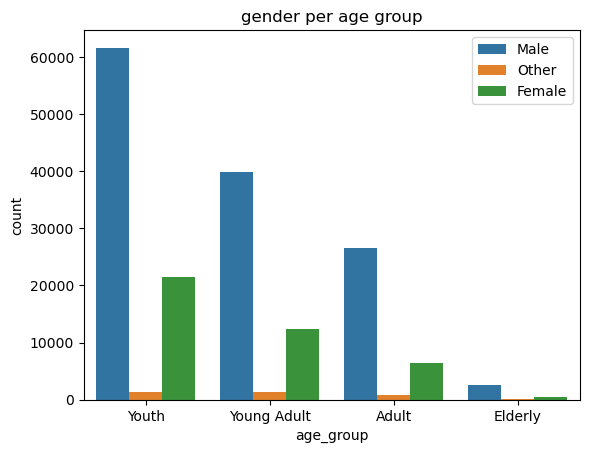

The analysis also shows that younger people have the tendency to travel longer than older people, it could be because of their risk tolerance, strength and eagernesss to migrate frequently etc.

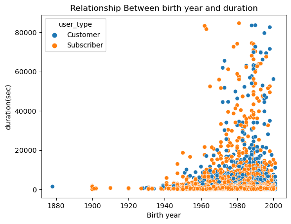

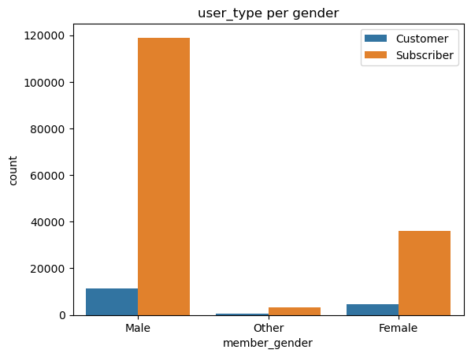

```
^C
```

[output not shown]